# T01. El terminal de Bash y los alineamientos

## Principales carpetas en Linux

```
/                    Direcotrio raíz.
├── dev              Archivos especiales de dispositivos.
├── etc              Configuración del sistema.
├── home             Carpetas de usuario.
├── media            Punto de montaje de medios extraíbles.
├── opt              Instalación manual de otros programas.
├── run              Datos variables del sistema
├── usr              Programas de usuario, aplicaciones...
│   ├── bin          Ejecutable
│   ├── lib          Librerías compartidas
│   ├── local        Programas instalados manualmente.
│   ├── sbin         Ejecutables de administración.
│   ├── share        Datos compartidos entre programas.
└── var              Registros que se actualizan (log files).
```

## Direcciones absolutas y relativas

`pwd` nos dice dónde estamos. Todos los comandos que usan archivos o carpetas (e.g., `mkdir`, `cd`, `ls`…) entienden los caminos absolutos (desde el directorio raíz) y los relativos.

### Direcciones relativas

- `../../usr/bin/needle`
- `bioinfo/results/2026-02-01`

### Direcciones absolutas

- `/home/usuario/Documentos/bioinfo/results/2026-02-01`
- `/usr/bin/needle`

## El PATH

La primera palabra en una orden debe ser el nombre de un archivo ejecutable. Para no tener que dar la dirección completa cada vez, Bash recuerda en qué carpetas suele haber archivos ejecutables y los busca allí, en el orden establecido.

```
echo $PATH
/usr/bin:/usr/local/bin:/opt/miniconda3/bin
```

Si instalamos ejecutables en una carpeta local, o bien la añadimos al PATH, o bien los invocamos con la dirección completa.

## Cómo pedir ayuda

```
NAME
       man - an interface to the system reference manuals

SYNOPSIS
       man [man options] [[section] page ...] ...
       man -k [apropos options] regexp ...
       man -K [man options] [section] term ...
       man -f [whatis options] page ...
       man -l [man options] file ...
       man -w|-W [man options] page ...
```

# Alineamientos

## Alineamientos globales

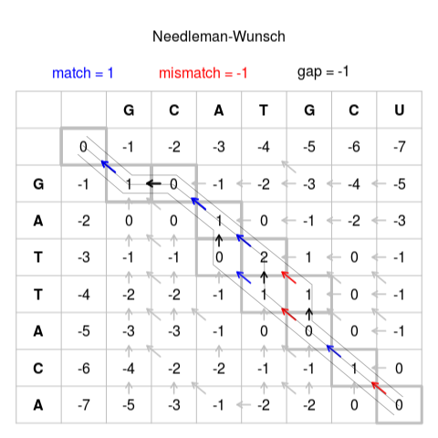

[<sub>By Slowkow - CC0</sub>](https://commons.wikimedia.org/w/index.php?curid=31963972)

Algoritmo de Needleman-Wunsch (programación dinámica). Garantiza el alineamiento *óptimo*. La puntución total es la suma de las puntuaciones de cada posición.

## Alineamientos globales

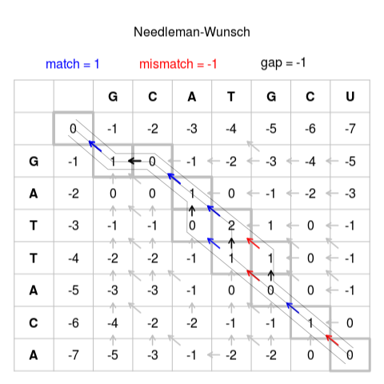

[<sub>By Slowkow - CC0</sub>](https://commons.wikimedia.org/w/index.php?curid=31963972)

Tres alineamientos de puntuación óptima de 0:

```
                     GCATG-CU      GCA-TGCU      GCAT-GCU
                     G-ATTACA      G-ATTACA      G-ATTACA
```

## Esquemas de puntuación

- Simple:
  - Coincidencia: +1
  - *Mismatch*: -1
  - *indel*: -1
- Para favorecer alineamientos con pocos gaps más largos en lugar de muchos y cortos, se penaliza más la **aparición** que la **extensión** del *gap*.
- Matrices de similitud: puntúan cada cambio posible y definen lo que entendemos por un *buen* alineamiento.

## Matrices de similitud

|  | A | G | C | T |
| --- | --- | --- | --- | --- |
| A | 1 | -1 | -1 | -1 |
| G | -1 | 1 | -1 | -1 |
| C | -1 | -1 | 1 | -1 |
| T | -1 | -1 | -1 | 4 |

Este esquema de puntuación valora más las coincidencias de timinas en el alineamiento.

## Matriz PAM

[interactive chart not shown]

<sub>By Ruth Dayhoff</sub>

Margaret Dayhoff introdujo las matrices PAM en 1978 para el alineamiento de proteínas.

Una matriz PAM$_n$ corresponde al tiempo suficiente para que *n* mutaciones hayan aparecido entre 100 aminoácidos.

## PAM250

```
   A  R  N  D  C  Q  E  G  H  I  L  K  M  F  P  S  T  W  Y  V  B  Z  X  *
A  2 -2  0  0 -2  0  0  1 -1 -1 -2 -1 -1 -3  1  1  1 -6 -3  0  0  0  0 -8
R -2  6  0 -1 -4  1 -1 -3  2 -2 -3  3  0 -4  0  0 -1  2 -4 -2 -1  0 -1 -8
N  0  0  2  2 -4  1  1  0  2 -2 -3  1 -2 -3  0  1  0 -4 -2 -2  2  1  0 -8
D  0 -1  2  4 -5  2  3  1  1 -2 -4  0 -3 -6 -1  0  0 -7 -4 -2  3  3 -1 -8
C -2 -4 -4 -5 12 -5 -5 -3 -3 -2 -6 -5 -5 -4 -3  0 -2 -8  0 -2 -4 -5 -3 -8
Q  0  1  1  2 -5  4  2 -1  3 -2 -2  1 -1 -5  0 -1 -1 -5 -4 -2  1  3 -1 -8
E  0 -1  1  3 -5  2  4  0  1 -2 -3  0 -2 -5 -1  0  0 -7 -4 -2  3  3 -1 -8
G  1 -3  0  1 -3 -1  0  5 -2 -3 -4 -2 -3 -5  0  1  0 -7 -5 -1  0  0 -1 -8
H -1  2  2  1 -3  3  1 -2  6 -2 -2  0 -2 -2  0 -1 -1 -3  0 -2  1  2 -1 -8
I -1 -2 -2 -2 -2 -2 -2 -3 -2  5  2 -2  2  1 -2 -1  0 -5 -1  4 -2 -2 -1 -8
L -2 -3 -3 -4 -6 -2 -3 -4 -2  2  6 -3  4  2 -3 -3 -2 -2 -1  2 -3 -3 -1 -8
K -1  3  1  0 -5  1  0 -2  0 -2 -3  5  0 -5 -1  0  0 -3 -4 -2  1  0 -1 -8
M -1  0 -2 -3 -5 -1 -2 -3 -2  2  4  0  6  0 -2 -2 -1 -4 -2  2 -2 -2 -1 -8
F -3 -4 -3 -6 -4 -5 -5 -5 -2  1  2 -5  0  9 -5 -3 -3  0  7 -1 -4 -5 -2 -8
P  1  0  0 -1 -3  0 -1  0  0 -2 -3 -1 -2 -5  6  1  0 -6 -5 -1 -1  0 -1 -8
S  1  0  1  0  0 -1  0  1 -1 -1 -3  0 -2 -3  1  2  1 -2 -3 -1  0  0  0 -8
T  1 -1  0  0 -2 -1  0  0 -1  0 -2  0 -1 -3  0  1  3 -5 -3  0  0 -1  0 -8
W -6  2 -4 -7 -8 -5 -7 -7 -3 -5 -2 -3 -4  0 -6 -2 -5 17  0 -6 -5 -6 -4 -8
Y -3 -4 -2 -4  0 -4 -4 -5  0 -1 -1 -4 -2  7 -5 -3 -3  0 10 -2 -3 -4 -2 -8
V  0 -2 -2 -2 -2 -2 -2 -1 -2  4  2 -2  2 -1 -1 -1  0 -6 -2  4 -2 -2 -1 -8
B  0 -1  2  3 -4  1  3  0  1 -2 -3  1 -2 -4 -1  0  0 -5 -3 -2  3  2 -1 -8
Z  0  0  1  3 -5  3  3  0  2 -2 -3  0 -2 -5  0  0 -1 -6 -4 -2  2  3 -1 -8
X  0 -1  0 -1 -3 -1 -1 -1 -1 -1 -1 -1 -1 -2 -1  0  0 -4 -2 -1 -1 -1 -1 -8
* -8 -8 -8 -8 -8 -8 -8 -8 -8 -8 -8 -8 -8 -8 -8 -8 -8 -8 -8 -8 -8 -8 -8  1
```

## BLOSUM (*block substitution matrix*)

```
   A  R  N  D  C  Q  E  G  H  I  L  K  M  F  P  S  T  W  Y  V  B  J  Z  X  *
A  4 -1 -2 -2  0 -1 -1  0 -2 -1 -1 -1 -1 -2 -1  1  0 -3 -2  0 -2 -1 -1 -1 -4
R -1  5  0 -2 -3  1  0 -2  0 -3 -2  2 -1 -3 -2 -1 -1 -3 -2 -3 -1 -2  0 -1 -4
N -2  0  6  1 -3  0  0  0  1 -3 -3  0 -2 -3 -2  1  0 -4 -2 -3  4 -3  0 -1 -4
D -2 -2  1  6 -3  0  2 -1 -1 -3 -4 -1 -3 -3 -1  0 -1 -4 -3 -3  4 -3  1 -1 -4
C  0 -3 -3 -3  9 -3 -4 -3 -3 -1 -1 -3 -1 -2 -3 -1 -1 -2 -2 -1 -3 -1 -3 -1 -4
Q -1  1  0  0 -3  5  2 -2  0 -3 -2  1  0 -3 -1  0 -1 -2 -1 -2  0 -2  4 -1 -4
E -1  0  0  2 -4  2  5 -2  0 -3 -3  1 -2 -3 -1  0 -1 -3 -2 -2  1 -3  4 -1 -4
G  0 -2  0 -1 -3 -2 -2  6 -2 -4 -4 -2 -3 -3 -2  0 -2 -2 -3 -3 -1 -4 -2 -1 -4
H -2  0  1 -1 -3  0  0 -2  8 -3 -3 -1 -2 -1 -2 -1 -2 -2  2 -3  0 -3  0 -1 -4
I -1 -3 -3 -3 -1 -3 -3 -4 -3  4  2 -3  1  0 -3 -2 -1 -3 -1  3 -3  3 -3 -1 -4
L -1 -2 -3 -4 -1 -2 -3 -4 -3  2  4 -2  2  0 -3 -2 -1 -2 -1  1 -4  3 -3 -1 -4
K -1  2  0 -1 -3  1  1 -2 -1 -3 -2  5 -1 -3 -1  0 -1 -3 -2 -2  0 -3  1 -1 -4
M -1 -1 -2 -3 -1  0 -2 -3 -2  1  2 -1  5  0 -2 -1 -1 -1 -1  1 -3  2 -1 -1 -4
F -2 -3 -3 -3 -2 -3 -3 -3 -1  0  0 -3  0  6 -4 -2 -2  1  3 -1 -3  0 -3 -1 -4
P -1 -2 -2 -1 -3 -1 -1 -2 -2 -3 -3 -1 -2 -4  7 -1 -1 -4 -3 -2 -2 -3 -1 -1 -4
S  1 -1  1  0 -1  0  0  0 -1 -2 -2  0 -1 -2 -1  4  1 -3 -2 -2  0 -2  0 -1 -4
T  0 -1  0 -1 -1 -1 -1 -2 -2 -1 -1 -1 -1 -2 -1  1  5 -2 -2  0 -1 -1 -1 -1 -4
W -3 -3 -4 -4 -2 -2 -3 -2 -2 -3 -2 -3 -1  1 -4 -3 -2 11  2 -3 -4 -2 -2 -1 -4
Y -2 -2 -2 -3 -2 -1 -2 -3  2 -1 -1 -2 -1  3 -3 -2 -2  2  7 -1 -3 -1 -2 -1 -4
V  0 -3 -3 -3 -1 -2 -2 -3 -3  3  1 -2  1 -1 -2 -2  0 -3 -1  4 -3  2 -2 -1 -4
B -2 -1  4  4 -3  0  1 -1  0 -3 -4  0 -3 -3 -2  0 -1 -4 -3 -3  4 -3  0 -1 -4
J -1 -2 -3 -3 -1 -2 -3 -4 -3  3  3 -3  2  0 -3 -2 -1 -2 -1  2 -3  3 -3 -1 -4
Z -1  0  0  1 -3  4  4 -2  0 -3 -3  1 -1 -3 -1  0 -1 -2 -2 -2  0 -3  4 -1 -4
X -1 -1 -1 -1 -1 -1 -1 -1 -1 -1 -1 -1 -1 -1 -1 -1 -1 -1 -1 -1 -1 -1 -1 -1 -4
* -4 -4 -4 -4 -4 -4 -4 -4 -4 -4 -4 -4 -4 -4 -4 -4 -4 -4 -4 -4 -4 -4 -4 -4  1
```

B = {D, N}, J = {I, L}, Z = {E, Q}, X = {todos}, * = STOP

## BLOSUM vs PAM

Correspondencia aproximada entre matrices PAM y BLOSUM:

| PAM | BLOSUM |
| --- | --- |
| PAM100 | BLOSUM90 |
| PAM120 | BLOSUM80 |
| PAM160 | BLOSUM62 |
| PAM200 | BLOSUM50 |
| PAM250 | BLOSUM45 |

## Alineamientos locales

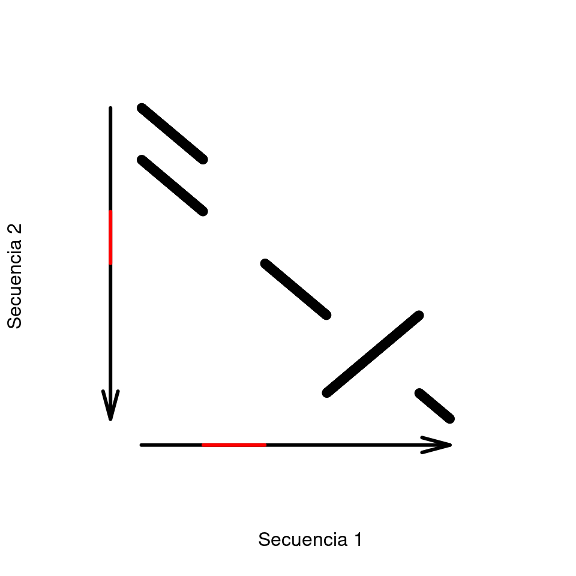

- La figura representa 5 alineamientos **locales** entre dos secuencias de ADN.
- Se observa una duplicación en la secuencia 2.
- Y una inversión (posible en nucleótidos).
- Hay también una región sin homología (en rojo).

## Algoritmo de Smith-Waterman

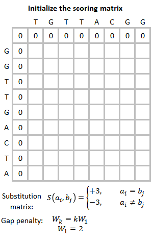

[<sub>By Yz cs5160 - CC BY-SA 4.0</sub>](https://commons.wikimedia.org/w/index.php?curid=54416043)

# Alineamientos múltiples

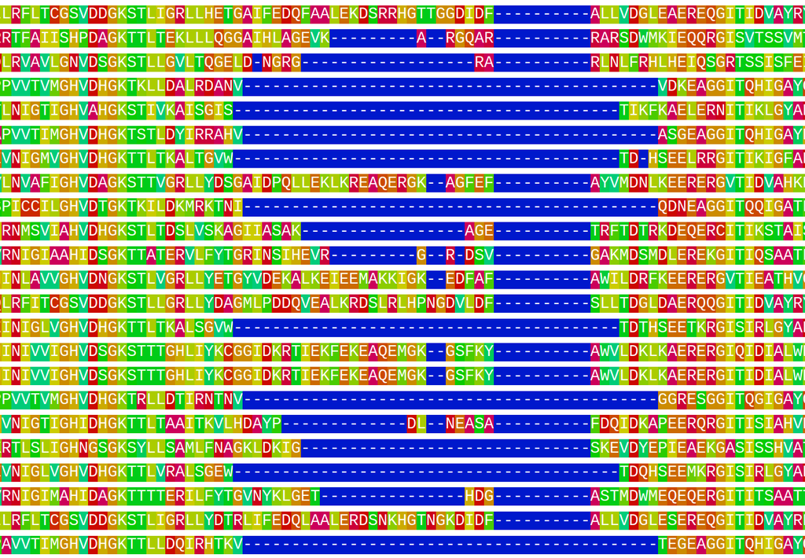

Ejemplo de alineamiento de múltiples secuencias, con una región dudosa.

## CLUSTAL

- Diferentes versiones: CLUSTAL (1988), CLUSTAL V (1992), CLUSTAL W (1994), CLUSTAL X (1997), CLUSTAL 2 (2007), CLUSTAL $\Omega$ (2011).
- **Alineamiento progresivo**: se empieza alineando las parejas de secuencias más semejantes.
- El **árbol guía** que determina el orden de incorporación de secuencias en el alineamiento se obtiene de una comparación inicial de todos los pares de secuencias.

http://www.clustal.org/

## MUSCLE

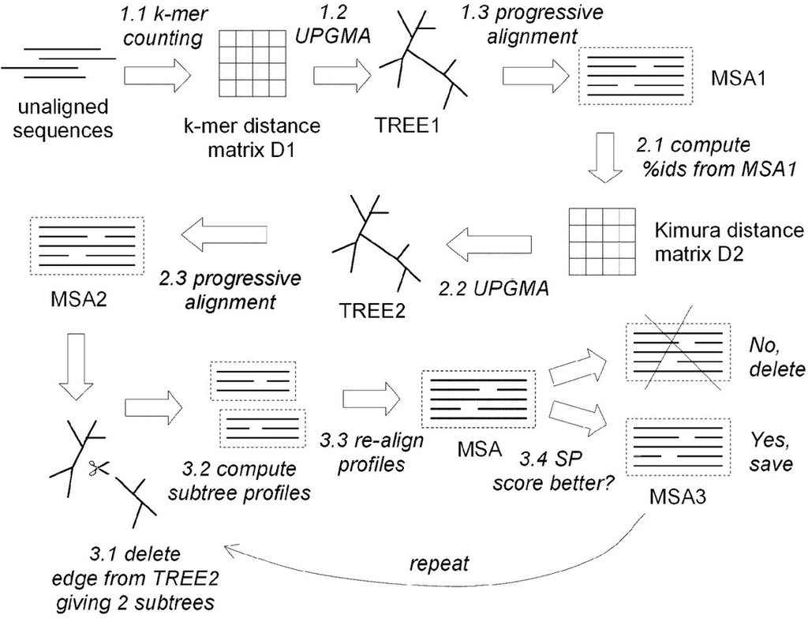

[By Edgar, 2004. CC BY](https://doi.org/10.1093/nar/gkh340)

## Otros programas

| Nombre | Descripción | Licencia |
| --- | --- | --- |
| DECIPHER | Alineamiento global, progresivo e iterativo en R | GPL |
| MAFFT | Alineamiento local y global, progresivo e iterativo | BSD |
| T-Coffee | Alineamiento local y global, progresivo. Puede usar estructura 3D. Evalúa el alineamiento | GPL2 |

# Mapaje de lecturas cortas

## Datos

- Lecturas cortas (<300 bases) de un individuo, obtenidas con Illumina.
- Las lecturas pueden estar emparejadas.
- Contienen errores, normalmente < 1%.
- Archivos FASTQ con miles de secuencias.
- Problema: alinear cada lectura al genoma de referencia.

## Formato FASTQ

```
@SRR001666.1 071112_SLXA-EAS1_s_7:5:1:817:345 length=72
GGGTGATGGCCGCTGCCGATGGCGTCAAATCCCACCAAGTTACCCTTAACAACTTAAGGGTTTTCAAATAGA
+SRR001666.1 071112_SLXA-EAS1_s_7:5:1:817:345 length=72
IIIIIIIIIIIIIIIIIIIIIIIIIIIIII9IG9ICIIIIIIIIIIIIIIIIIIIIDIIIIIII>IIIIII/
@SRR001666.2 071112_SLXA-EAS1_s_7:5:1:801:338 length=72
GTTCAGGGATACGACGTTTGTATTTTAAGAATCTGAAGCAGAAGTCGATGATAATACGCGTCGTTTTATCAT
+SRR001666.2 071112_SLXA-EAS1_s_7:5:1:801:338 length=72
IIIIIIIIIIIIIIIIIIIIIIIIIIIIIIII6IBIIIIIIIIIIIIIIIIIIIIIIIGII>IIIII-I)8I
```

4 líneas por secuencia: `@`nombre, secuencia,`+`(nombre, opcional) y calidades.

## Formato FASTQ. Calidades

```
  SSSSSSSSSSSSSSSSSSSSSSSSSSSSSSSSSSSSSSSSS.....................................................
  ..........................XXXXXXXXXXXXXXXXXXXXXXXXXXXXXXXXXXXXXXXXXXXXXX......................
  ...............................IIIIIIIIIIIIIIIIIIIIIIIIIIIIIIIIIIIIIIIII......................
  .................................JJJJJJJJJJJJJJJJJJJJJJJJJJJJJJJJJJJJJJJJ.....................
  LLLLLLLLLLLLLLLLLLLLLLLLLLLLLLLLLLLLLLLLLL....................................................
  PPPPPPPPPPPPPPPPPPPPPPPPPPPPPPPPPPPPPPPPPPPPPPPPPPPPPPPPPPPPPPPPPPPPPPPPPPPPPPPPPPPPPPPPPPPPPP
  !"#$%&'()*+,-./0123456789:;<=>?@ABCDEFGHIJKLMNOPQRSTUVWXYZ[\]^_`abcdefghijklmnopqrstuvwxyz{|}~
  |                         |    |        |                              |                     |
 33                        59   64       73                            104                   126
  0........................26...31.......40
                           -5....0........9.............................40
                                 0........9.............................40
                                    3.....9..............................41
  0.2......................26...31........41
  0..................20........30........40........50..........................................93

 S - Sanger        Phred+33,  typically (0, 40)       J - Illumina 1.5+ Phred+64,  typically (3, 41)
 X - Solexa        Solexa+64, typically (-5, 40)      L - Illumina 1.8+ Phred+33,  typically (0, 41)
 I - Illumina 1.3+ Phred+64,  typically (0, 40)       P - PacBio        Phred+33,  typically (0, 93)
```

## Formato FASTQ. Nivel de calidad Phred.

$Q = -10 \cdot \log_{10}P$

$P = 10^{-\frac{Q}{10}}$

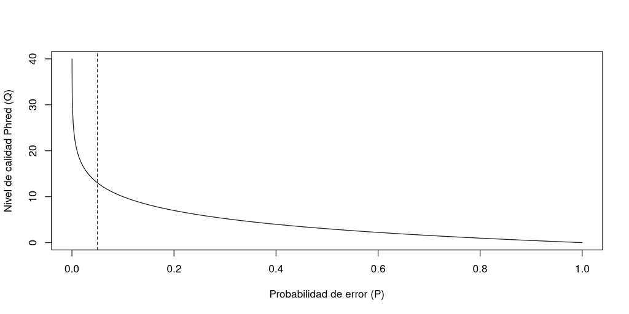

## Mapeo

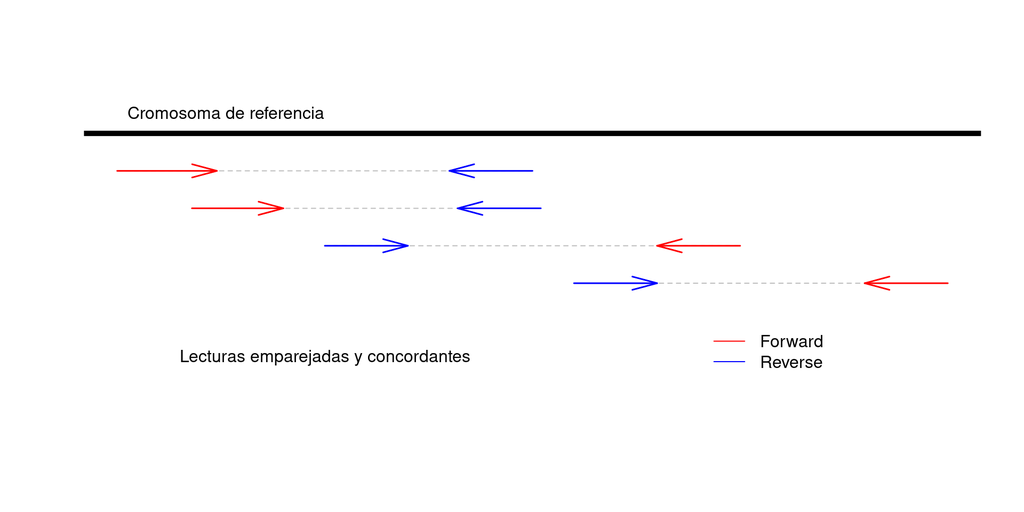

## Genotecas

- Los protocolos que incluyen PCR pueden introducir sesgos de cobertura.
- Si la fragmentación es aleatoria, no esperamos lecturas que mapeen exactamente en la misma posición (duplicaciones por PCR?).
- Los protocolos con fragmentación no aleatoria (digestión enzimática) no permiten identificar las duplicaciones por PCR.

## Ejemplo

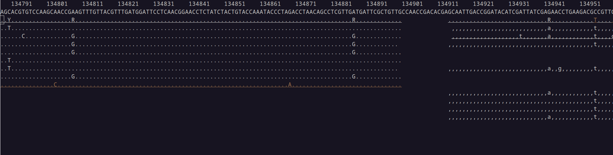

## Limitaciones de la estrategia

El uso de un genoma de referencia para descubrir variación genética entre las muestras implica que:

1. La referencia puede contener errores.
2. Sólo podemos comparar la fracción común o mapeable.
3. Las muestras más parecidas a la referencia mapean mejor.

## ¿Cómo se guardan los resultados?

```
Coor      12345678901234  5678901234567890123456789012345
ref       AGCATGTTAGATAA**GATAGCTGTGCTAGTAGGCAGTCAGCGCCAT

+r001/1         TTAGATAAAGGATA*CTG
+r002          aaaAGATAA*GGATA
+r003        gcctaAGCTAA
+r004                      ATAGCT..............TCAGC
-r003                             ttagctTAGGC
-r001/2                                         CAGCGGCAT
```

Alineamiento de 6 lecturas cortas a un genoma de referencia. r001/1 i r001/2: lecturas apareadas. Minúsculas: extremos no alineados.

## Formato [SAM](http://samtools.github.io/hts-specs/SAMv1.pdf). Ejemplo

```
@HD VN:1.6 SO:coordinate
@SQ SN:ref LN:45
r001   99 ref  7 30 8M2I4M1D3M  = 37  39 TTAGATAAAGGATACTG *
r002    0 ref  9 30 3S6M1P1I4M  *  0   0 AAAAGATAAGGATA    *
r003    0 ref  9 30 5S6M        *  0   0 GCCTAAGCTAA       * SA:Z:ref,29,-,6H5M,17,0;
r004    0 ref 16 30 6M14N5M     *  0   0 ATAGCTTCAGC       *
r003 2064 ref 29 17 6H5M        *  0   0 TAGGC             * SA:Z:ref,9,+,5S6M,30,1;
r001  147 ref 37 30 9M          =  7 -39 CAGCGGCAT         * NM:i:1
```

## Formato SAM. Campos obligatorios

| Columna | Nombre | Tipo | Descripción |
| --- | --- | --- | --- |
| 1 | QNAME | caracteres | Nombre de la secuencia corta |
| 2 | FLAG | número | Marcas binarias |
| 3 | RNAME | caracteres | Nombre de la secuencia de referencia |
| 4 | POS | número | Posición izquierda de mapeo (base 1) |
| 5 | MAPQ | número | Calidad de mapaje (escala Phred) |
| 6 | CIGAR | caracteres | Descripción de alineamiento codificada |
| 7 | RNEXT | caracteres | Referencia donde mapea la pareja (si hay) |
| 8 | PNEXT | número | Posición de la pareja (si hay) |
| 9 | TLEN | número | Longitud observada del fragmento |
| 10 | SEQ | caracteres | Secuencia del segmento |
| 11 | QUAL | caracteres | ASCII de calidades de bases (+33, en Phred) |

**Hay 10 tipos**

**de personas:**

**las que entienden**

**binario y**

**las que no**

## Formato SAM. Marcas binarias

| Decimal | Binario | Descripción |
| --- | --- | --- |
| 1 | 000000000001 | Lecturas emparejadas. |
| 2 | 000000000010 | Alineamiento concordante. |
| 4 | 000000000100 | Lectura no mapeada. |
| 8 | 000000001000 | Pareja no mapeada. |
| 16 | 000000010000 | SEQ invertida y complementada. |
| 32 | 000000100000 | SEQ de pareja invertida-complementada. |
| 64 | 000001000000 | Primera lectura de la pareja. |
| 128 | 000010000000 | Última lectura de la pareja. |
| 256 | 000100000000 | Alineamiento secundario. |
| 512 | 001000000000 | No pasa los filtros de calidad. |